# Simulating dynamic systems in R

## 6.5 How do I add kicks that hit both constructs at once (a common cause)?

Draw one shared kick per small step and add it to both: `sharedKick <- Gs * sqrt(dt) * rnorm(1)`, then add `sharedKick` to both state updates, next to each construct’s own kick.

A shared kick is an event that hits both at the same moment (a thunderstorm, a fight, a bad night). It makes the two move together **without** any coupling: `A12` and `A21` stay 0. Coupling acts with a delay and has a direction; a shared kick acts at once and has none.

```r
library(ggplot2)

times <- seq(from = 0, to = 24, by = 0.25)
Nsteps <- 20
A1 <- -0.6; A2 <- -0.4
A12 <- 0; A21 <- 0                # <-- no coupling at all
rest <- c(5, 5)
B1 <- -(A1*rest[1] + A12*rest[2]); B2 <- -(A21*rest[1] + A2*rest[2])
G1 <- 0.3                         # Albert's own kicks
G2 <- 0.35                        # the rabbit's own kicks
Gs <- 1.2                         # <-- NEW: shared kicks

set.seed(27)
Albert <- Rabbit <- rep(NA, length(times))
albertState <- rest[1]; rabbitState <- rest[2]
Albert[1] <- albertState; Rabbit[1] <- rabbitState
for (i in 2:length(times)) {
  dt <- (times[i] - times[i-1]) / Nsteps
  for (stepi in 1:Nsteps) {
    dAlbert <- A1*albertState + A12*rabbitState + B1
    dRabbit <- A21*albertState + A2*rabbitState + B2
    sharedKick <- Gs * sqrt(dt) * rnorm(1)   # <-- NEW
    albertState <- albertState + dAlbert * dt + G1 * sqrt(dt) * rnorm(1) + sharedKick   # <-- CHANGE
    rabbitState <- rabbitState + dRabbit * dt + G2 * sqrt(dt) * rnorm(1) + sharedKick   # <-- CHANGE
  }
  Albert[i] <- albertState; Rabbit[i] <- rabbitState
}

cor(Albert, Rabbit)               # high, although neither affects the other
```

```
## [1] 0.8962269
```

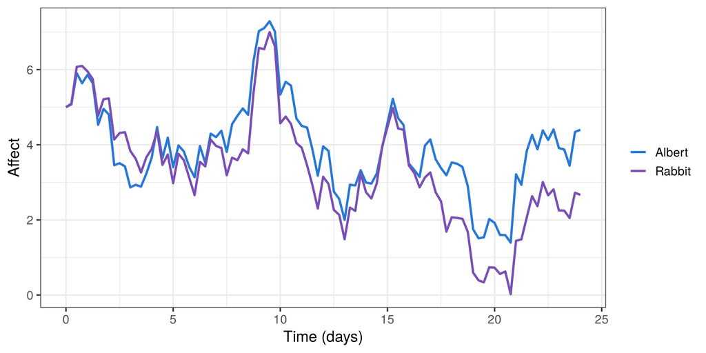

```r
long <- rbind(data.frame(time = times, value = Albert, who = "Albert"),
              data.frame(time = times, value = Rabbit, who = "Rabbit"))
ggplot(long, aes(x = time, y = value, colour = who)) +
  geom_line(linewidth = 1) +
  scale_colour_manual(values = c(Albert = "#2a78d6", Rabbit = "#7a4fb5")) +
  theme_bw(base_size = 14) +
  labs(x = "Time (days)", y = "Affect", colour = NULL)
```

With three constructs, add the same `sharedKick` to the update of each construct the common cause hits.

## 6.6 How do I give each person their own coupling strength?

Draw a coupling per person, `A21_i <- A21typical + A21sd * rnorm(1)`, and check for every person that the system is stable (`A1*A2 - A12*A21_i > 0`, see Stability). Redraw the value if it is not.

A coupling may be positive for some people and negative for others, so here an additive normal difference is fine, unlike for `A` and `G`. But a strong coupling can make one person’s system run away, which is rarely what you want.

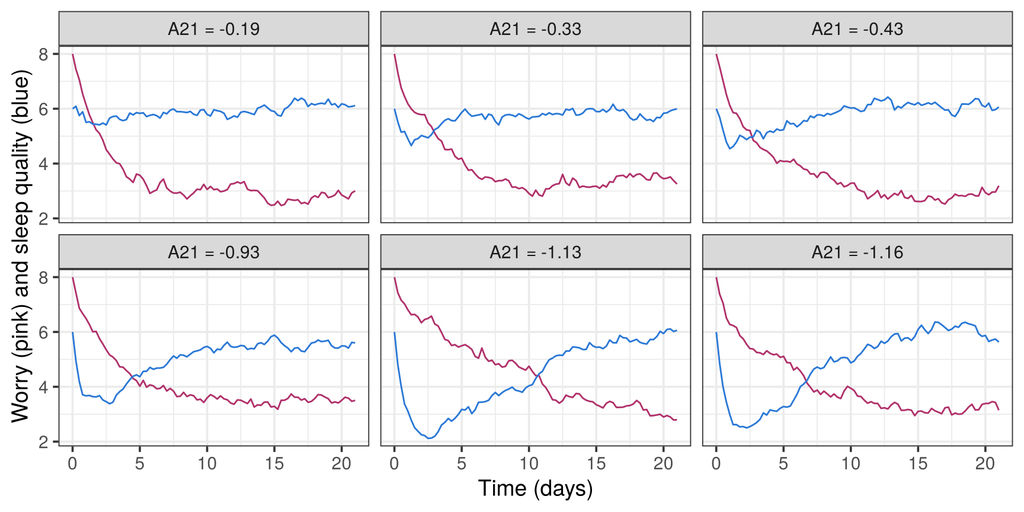

```r
library(ggplot2)

Npeople <- 6
times <- seq(from = 0, to = 21, by = 0.25)
Nsteps <- 20
A1 <- -0.5; A2 <- -1.0; A12 <- -0.3
rest <- c(3, 6)
G1 <- 0.25; G2 <- 0.25
A21typical <- -0.4                # <-- NEW: typical effect of worry on sleep
A21sd <- 0.4                      # <-- NEW: how much people differ in it

set.seed(28)
people <- data.frame(id = 1:Npeople, A21 = NA)
for (p in 1:Npeople) {
  repeat {   # <-- NEW: draw until stable
    a21 <- A21typical + A21sd * rnorm(1)
    if (A1*A2 - A12*a21 > 0) break                                     # stable: keep it
  }
  people$A21[p] <- a21
}
people$label <- paste("A21 =", round(people$A21, 2))

dat <- NULL
for (p in 1:Npeople) {
  A21 <- people$A21[p]
  B1 <- -(A1*rest[1] + A12*rest[2]); B2 <- -(A21*rest[1] + A2*rest[2])
  worryState <- 8; sleepState <- rest[2]   # everyone starts with a very worried day
  Worry <- Sleep <- rep(NA, length(times))
  Worry[1] <- worryState; Sleep[1] <- sleepState
  for (i in 2:length(times)) {
    dt <- (times[i] - times[i-1]) / Nsteps
    for (stepi in 1:Nsteps) {
      dWorry <- A1*worryState + A12*sleepState + B1
      dSleep <- A21*worryState + A2*sleepState + B2
      worryState <- worryState + dWorry * dt + G1 * sqrt(dt) * rnorm(1)
      sleepState <- sleepState + dSleep * dt + G2 * sqrt(dt) * rnorm(1)
    }
    Worry[i] <- worryState; Sleep[i] <- sleepState
  }
  dat <- rbind(dat, data.frame(id = p, label = people$label[p], time = times,
                               Worry = Worry, Sleep = Sleep))
}

ggplot(dat, aes(x = time)) +
  geom_line(aes(y = Worry), colour = "#b0306a") +
  geom_line(aes(y = Sleep), colour = "#2a78d6") +
  facet_wrap(~ label) +
  theme_bw(base_size = 14) +
  labs(x = "Time (days)", y = "Worry (pink) and sleep quality (blue)")
```

# 7 Nonlinear rules

## 7.1 How do I add a threshold, e.g. rumination that starts below a mood of 50?

In every small step, check the current state and switch an extra term on or off: `moderator <- as.numeric(MoodState < threshold)`, then `dMood <- A*MoodState + B + Beffect * moderator`.

The moderator must be checked **inside** the small-step loop, because mood changes all the time. With these settings there are two stable states, 60 above the threshold and 40 below it, and the kicks sometimes throw mood from one to the other. For one stable state, set `Beffect <- 5` (below 50 an extra push up, e.g. coping); for no stable state, set `B <- 24` and `Beffect <- 4`. The script prints the two candidate resting levels; a candidate only counts if it lies on its own side of the threshold.

```r
library(ggplot2)

Npeople <- 6
times <- seq(from = 0, to = 56, by = 0.25)
Nsteps <- 20
A <- -0.5
B <- 30                           # above the threshold mood is pushed towards -B/A = 60
G <- 6
threshold <- 50                   # <-- NEW
Beffect <- -10   # <-- NEW: below 50, rumination lowers the push: towards 40

simulateMood <- function(initialMood, times, Nsteps){
  Nobs <- length(times)
  Mood <- rep(NA, Nobs)
  MoodState <- initialMood
  for(i in 1:Nobs){
    if(i > 1){
      dt <- (times[i] - times[i-1]) / Nsteps
      for(stepi in 1:Nsteps){
        moderator <- as.numeric(MoodState < threshold)     # <-- NEW: 1 below, 0 above
        dMood <- A*MoodState + B + Beffect*moderator       # <-- CHANGE
        kick <- G * sqrt(dt) * rnorm(1)
        MoodState <- MoodState + dMood * dt + kick
      }
    }
    Mood[i] <- MoodState
  }
  data.frame(time = times, Mood = Mood)
}

c(above = -B/A, below = -(B + Beffect)/A)    # the two candidate resting levels
```

```
## above below
##    60    40
```

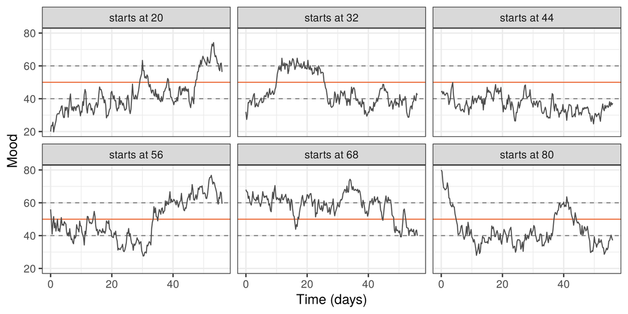

```r
set.seed(29)
startValues <- seq(from = 20, to = 80, length.out = Npeople)
dat <- NULL
for (p in 1:Npeople) {
  dat <- rbind(dat, data.frame(id = p, start = paste("starts at", round(startValues[p])),
                               simulateMood(startValues[p], times, Nsteps)))
}
dat$start <- factor(dat$start, levels = unique(dat$start))

ggplot(dat, aes(x = time, y = Mood)) +
  geom_hline(yintercept = threshold, colour = "#eb6834") +
  geom_hline(yintercept = c(-B/A, -(B + Beffect)/A), linetype = "dashed", colour = "grey50") +
  geom_line(colour = "grey30") +
  facet_wrap(~ start) +
  theme_bw(base_size = 14) +
  labs(x = "Time (days)", y = "Mood")
```

A rule that jumps at a threshold needs small steps: if one small step can carry mood far across the threshold, the switch comes too late. Check by doubling `Nsteps`.

## 7.2 How do I make the switch gradual instead of sudden?

Replace the 0/1 switch by a smooth one: `moderator <- plogis((threshold - MoodState) / width)`. It is close to 1 well below the threshold, 0.5 at the threshold, and close to 0 well above it.

`width` sets how gradual the switch is: a small width is almost the sudden switch, a large width spreads it over a wide range of moods.

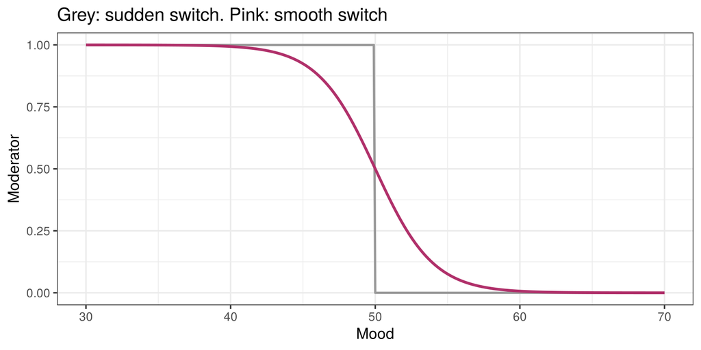

```r
library(ggplot2)

times <- seq(from = 0, to = 56, by = 0.25)
Nsteps <- 20
A <- -0.5; B <- 30; G <- 6
threshold <- 50
Beffect <- -10
width <- 2                        # <-- NEW: how gradual the switch is (mood units)

# what the switch looks like
switchCurve <- data.frame(Mood = seq(30, 70, 0.1))
switchCurve$sudden <- as.numeric(switchCurve$Mood < threshold)
switchCurve$smooth <- plogis((threshold - switchCurve$Mood) / width)
ggplot(switchCurve, aes(x = Mood)) +
  geom_line(aes(y = sudden), colour = "grey60", linewidth = 1) +
  geom_line(aes(y = smooth), colour = "#b0306a", linewidth = 1.2) +
  theme_bw(base_size = 14) +
  labs(x = "Mood", y = "Moderator", title = "Grey: sudden switch. Pink: smooth switch")
```

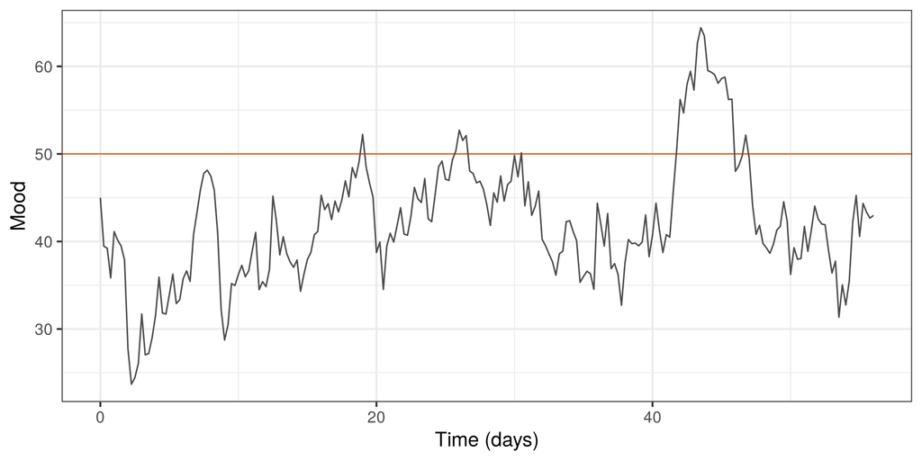

```r
simulateMood <- function(initialMood, times, Nsteps){
  Nobs <- length(times)
  Mood <- rep(NA, Nobs)
  MoodState <- initialMood
  for(i in 1:Nobs){
    if(i > 1){
      dt <- (times[i] - times[i-1]) / Nsteps
      for(stepi in 1:Nsteps){
        moderator <- plogis((threshold - MoodState) / width)   # <-- CHANGE: smooth switch
        dMood <- A*MoodState + B + Beffect*moderator
        kick <- G * sqrt(dt) * rnorm(1)
        MoodState <- MoodState + dMood * dt + kick
      }
    }
    Mood[i] <- MoodState
  }
  data.frame(time = times, Mood = Mood)
}

set.seed(30)
albert <- simulateMood(initialMood = 45, times = times, Nsteps = Nsteps)
ggplot(albert, aes(x = time, y = Mood)) +
  geom_hline(yintercept = threshold, colour = "#eb6834") +
  geom_line(colour = "grey30") +
  theme_bw(base_size = 14) +
  labs(x = "Time (days)", y = "Mood")
```

## 7.3 How do I make a switch with two thresholds (hysteresis)?

Set the moderator **once, before the loop**, and only change it when mood crosses one of the two thresholds: `if (MoodState < lowThreshold) moderator <- 1` and `if (MoodState > highThreshold) moderator <- 0`. In between it keeps its value.

Example: Albert starts seeking support when mood drops below 40 and keeps going until mood is back above 60. The same mood (say 50) can then come with two different rules, depending on where mood came from.

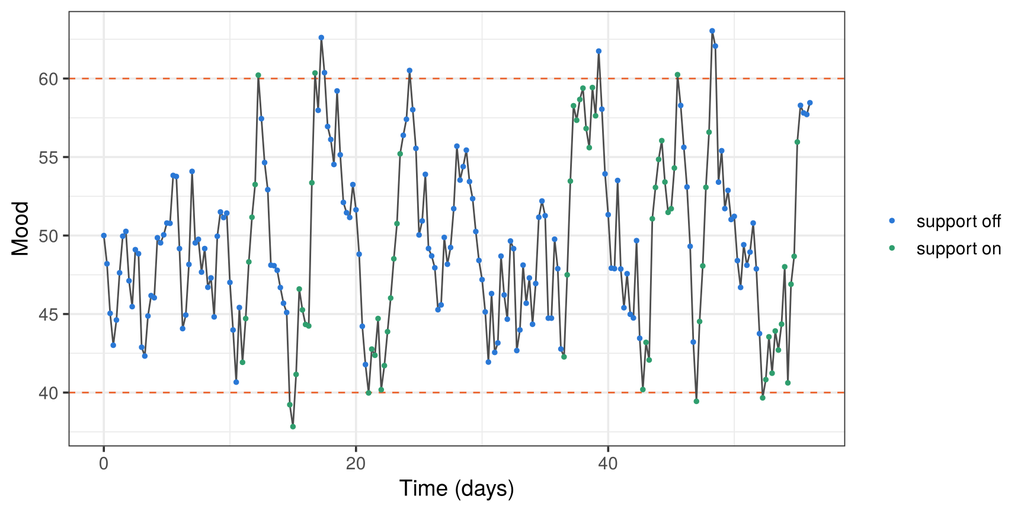

```r
library(ggplot2)

times <- seq(from = 0, to = 56, by = 0.25)
Nsteps <- 20
A <- -0.5
G <- 6
B <- 22                           # without support: mood drifts towards 44
Bsupport <- 10                    # with support: towards (22 + 10) / 0.5 = 64
lowThreshold <- 40                # <-- NEW: switch on below this
highThreshold <- 60               # <-- NEW: switch off above this

simulateMood <- function(initialMood, times, Nsteps){
  Nobs <- length(times)
  Mood <- Support <- rep(NA, Nobs)
  MoodState <- initialMood
  moderator <- 0   # <-- NEW: set once, before the loop
  for(i in 1:Nobs){
    if(i > 1){
      dt <- (times[i] - times[i-1]) / Nsteps
      for(stepi in 1:Nsteps){
        if (MoodState < lowThreshold) moderator <- 1   # <-- NEW: switch on
        if (MoodState > highThreshold) moderator <- 0  # <-- NEW: switch off; in between: keep
        dMood <- A*MoodState + B + Bsupport*moderator
        kick <- G * sqrt(dt) * rnorm(1)
        MoodState <- MoodState + dMood * dt + kick
      }
    }
    Mood[i] <- MoodState
    Support[i] <- moderator
  }
  data.frame(time = times, Mood = Mood, Support = Support)
}

set.seed(31)
albert <- simulateMood(initialMood = 50, times = times, Nsteps = Nsteps)

ggplot(albert, aes(x = time, y = Mood)) +
  geom_hline(yintercept = c(lowThreshold, highThreshold), colour = "#eb6834", linetype = "dashed") +
  geom_line(colour = "grey30") +
  geom_point(aes(colour = factor(Support)), size = 1) +
  scale_colour_manual(values = c("0" = "#2a78d6", "1" = "#2f9e6e"),
                      labels = c("support off", "support on")) +
  theme_bw(base_size = 14) +
  labs(x = "Time (days)", y = "Mood", colour = NULL)
```

## 7.4 How do I make a coupling that only works above a certain level?

Multiply the coupling by a switch that depends on the state of the driving construct: `dSleep <- A2*sleepState + B2 + A21 * (worryState - worryThreshold) * (worryState > worryThreshold)`.

Example: worry only harms sleep once it is above 5. Below 5, worry and sleep are unrelated. Written as `(worryState - worryThreshold)`, the effect starts at 0 at the threshold and grows from there, so there is no sudden jump. A linear model would spread this effect over all levels of worry.

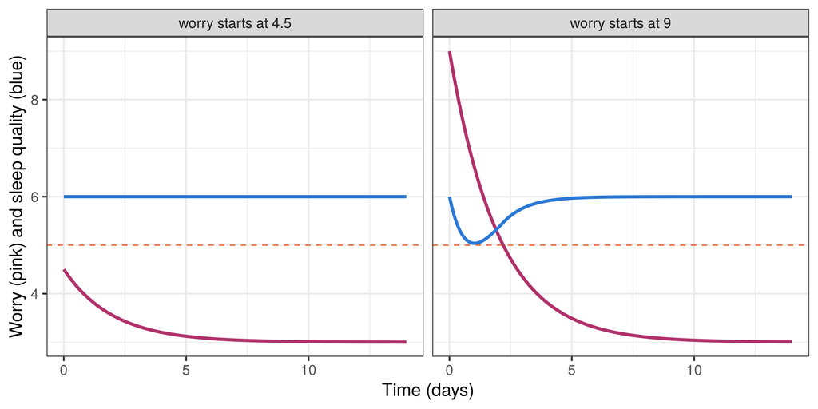

```r
library(ggplot2)

times <- seq(from = 0, to = 14, by = 0.1)
Nsteps <- 20
A1 <- -0.5; A2 <- -1.0
A21 <- -0.6                       # effect of worry on sleep, above the threshold
worryThreshold <- 5               # <-- NEW: worry only harms sleep above this
restWorry <- 3; restSleep <- 6
B1 <- -A1 * restWorry
B2 <- -A2 * restSleep             # worry rests below 5, so at rest the coupling is off

simulatePair <- function(startWorry){
  worryState <- startWorry; sleepState <- restSleep
  Worry <- Sleep <- rep(NA, length(times))
  Worry[1] <- worryState; Sleep[1] <- sleepState
  for (i in 2:length(times)) {
    dt <- (times[i] - times[i-1]) / Nsteps
    for (stepi in 1:Nsteps) {
      above <- as.numeric(worryState > worryThreshold)                         # <-- NEW
      dWorry <- A1*worryState + B1
      dSleep <- A2*sleepState + B2 + A21 * (worryState - worryThreshold) * above   # <-- CHANGE
      worryState <- worryState + dWorry * dt
      sleepState <- sleepState + dSleep * dt
    }
    Worry[i] <- worryState; Sleep[i] <- sleepState
  }
  data.frame(time = times, Worry = Worry, Sleep = Sleep)
}

dat <- rbind(data.frame(simulatePair(startWorry = 4.5), scenario = "worry starts at 4.5"),
             data.frame(simulatePair(startWorry = 9),   scenario = "worry starts at 9"))

ggplot(dat, aes(x = time)) +
  geom_hline(yintercept = worryThreshold, colour = "#eb6834", linetype = "dashed") +
  geom_line(aes(y = Worry), colour = "#b0306a", linewidth = 1.2) +
  geom_line(aes(y = Sleep), colour = "#2a78d6", linewidth = 1.2) +
  facet_wrap(~ scenario) +
  theme_bw(base_size = 14) +
  labs(x = "Time (days)", y = "Worry (pink) and sleep quality (blue)")
```

## 7.5 How do I keep the process itself between 0 and 100?

Simulate an unbounded state on a latent scale and transform it to the rating scale: `Mood <- 100 * plogis(latentState)`. `plogis()` maps any number to a value between 0 and 1.

Rounding and cutting off the ratings (see Round) only changes what is written down. Here the process itself cannot leave the scale: near 0 or 100, the same latent kick moves mood less. Choose the parameters on the latent scale: `qlogis(restMood / 100)` is the latent resting level.

```r
library(ggplot2)

times <- seq(from = 0, to = 28, by = 0.25)
Nsteps <- 20
A <- -0.5
restMood <- 85                                   # resting level on the 0-100 scale
restLatent <- qlogis(restMood / 100)   # <-- NEW: the same level on the latent scale (1.73)
B <- -A * restLatent
G <- 0.6                                         # kick strength on the LATENT scale

simulateMood <- function(initialMood, times, Nsteps){
  Nobs <- length(times)
  Mood <- Latent <- rep(NA, Nobs)
  latentState <- qlogis(initialMood / 100)       # <-- NEW: start on the latent scale
  for(i in 1:Nobs){
    if(i > 1){
      dt <- (times[i] - times[i-1]) / Nsteps
      for(stepi in 1:Nsteps){
        dLatent <- A*latentState + B
        kick <- G * sqrt(dt) * rnorm(1)
        latentState <- latentState + dLatent * dt + kick
      }
    }
    Latent[i] <- latentState
    Mood[i] <- 100 * plogis(latentState)          # <-- NEW: back to the 0-100 scale
  }
  data.frame(time = times, Latent = Latent, Mood = Mood)
}

set.seed(32)
albert <- simulateMood(initialMood = 85, times = times, Nsteps = Nsteps)
range(albert$Mood)                                # never outside 0-100
```

```
## [1] 56.48312 93.24829
```

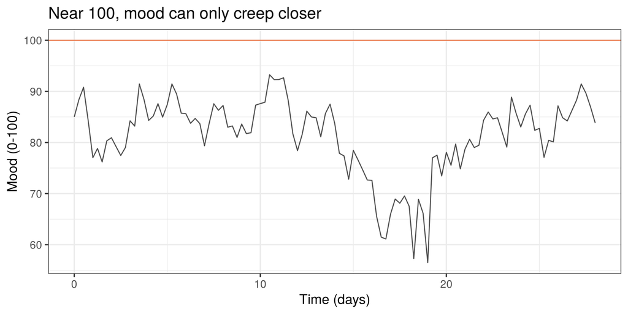

```r
ggplot(albert, aes(x = time, y = Mood)) +
  geom_hline(yintercept = 100, colour = "#eb6834") +
  geom_line(colour = "grey30") +
  theme_bw(base_size = 14) +
  labs(x = "Time (days)", y = "Mood (0-100)",
       title = "Near 100, mood can only creep closer")
```

On the latent scale everything is linear, but on the rating scale it is not: the same `A` and `G` look different near the edges than in the middle. Say this when you interpret your parameters.

# 8 Shocks and events

In all shocks in this section, a shock is a jump of size `dose` in one state at the moment of the shock. In a **transient** shock that state is mood itself. In the other types the jump goes into a second, unmeasured state (the shock process), which then pushes mood for as long as it is not 0.

## 8.1 How do I add a one-off event that hits mood directly (transient shock)?

At the rating time of the shock, add `dose` to mood: `if (any(abs(times[i] - shockTimes) < 1e-8)) MoodState <- MoodState + dose`. This line goes **outside** the small-step loop.

After the jump, only Albert’s own pull (`A`) brings mood back. Half of the shock is gone after `log(2) / -A` days. The shock times must be among the rating times; see Random events for shocks at any moment.

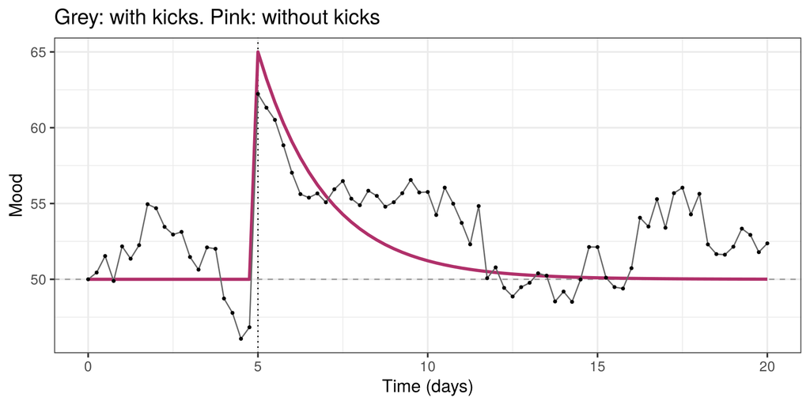

```r
library(ggplot2)

times <- seq(from = 0, to = 20, by = 0.25)
Nsteps <- 20
A <- -0.5
restMood <- 50
B <- -A * restMood
G <- 3
shockTimes <- 5                   # <-- NEW: the event happens on day 5
dose <- 15                        # <-- NEW: it lifts mood by 15 at once

simulateMood <- function(G, times, Nsteps){
  Nobs <- length(times)
  Mood <- rep(NA, Nobs)
  MoodState <- restMood
  for(i in 1:Nobs){
    if(i > 1){
      dt <- (times[i] - times[i-1]) / Nsteps
      for(stepi in 1:Nsteps){
        dMood <- A*MoodState + B
        kick <- G * sqrt(dt) * rnorm(1)
        MoodState <- MoodState + dMood * dt + kick
      }
    }
    if(any(abs(times[i] - shockTimes) < 1e-8)) MoodState <- MoodState + dose   # <-- NEW: the shock
    Mood[i] <- MoodState
  }
  data.frame(time = times, Mood = Mood)
}

set.seed(33)
albert <- simulateMood(G = G, times = times, Nsteps = Nsteps)
clean <- simulateMood(G = 0, times = times, Nsteps = Nsteps)   # the same without kicks

ggplot(albert, aes(x = time, y = Mood)) +
  geom_vline(xintercept = shockTimes, linetype = "dotted") +
  geom_hline(yintercept = restMood, linetype = "dashed", colour = "grey60") +
  geom_line(data = clean, colour = "#b0306a", linewidth = 1.2) +
  geom_line(colour = "grey40") + geom_point(size = 0.8) +
  theme_bw(base_size = 14) +
  labs(x = "Time (days)", y = "Mood", title = "Grey: with kicks. Pink: without kicks")
```

Why `abs(times[i] - shockTimes) < 1e-8` and not `times[i] == shockTimes`? Numbers from `seq()` are not always exact (0.1 + 0.2 is not exactly 0.3), so `==` can miss the shock without any error message.

## 8.2 How do I add an event that starts a process of its own that fades (dissipative shock)?

Add a second state, `InputState`, that fades by its own rule, `dInput <- Ainput * InputState`, and pushes mood: `dMood <- A*MoodState + B + C*InputState`. The shock adds `dose` to `InputState`, not to mood.

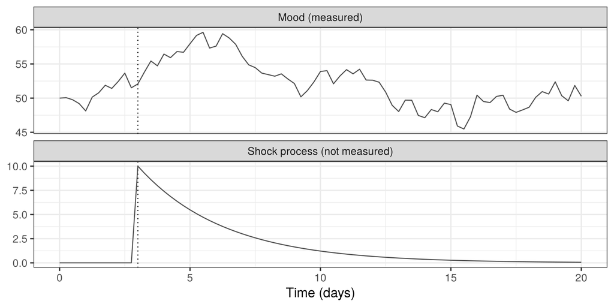

```r
library(ggplot2)

times <- seq(from = 0, to = 20, by = 0.25)
Nsteps <- 20
A <- -0.5
restMood <- 50
B <- -A * restMood
G <- 3
C <- 1                            # <-- NEW: how strongly the shock process pushes mood
Ainput <- -0.3                    # <-- NEW: how fast the shock process fades (per day)
shockTimes <- 3
dose <- 10                        # size of the shock process right after the event

simulateMood <- function(G, times, Nsteps){
  Nobs <- length(times)
  Mood <- Input <- rep(NA, Nobs)
  MoodState <- restMood
  InputState <- 0   # <-- NEW: no shock process yet
  for(i in 1:Nobs){
    if(i > 1){
      dt <- (times[i] - times[i-1]) / Nsteps
      for(stepi in 1:Nsteps){
        dMood <- A*MoodState + B + C*InputState   # <-- CHANGE: pushed by the process
        dInput <- Ainput*InputState                       # <-- NEW: the process fades
        kick <- G * sqrt(dt) * rnorm(1)
        MoodState <- MoodState + dMood * dt + kick
        InputState <- InputState + dInput * dt            # <-- NEW
      }
    }
    if(any(abs(times[i] - shockTimes) < 1e-8)) InputState <- InputState + dose   # <-- CHANGE
    Mood[i] <- MoodState
    Input[i] <- InputState
  }
  data.frame(time = times, Mood = Mood, Input = Input)
}

set.seed(34)
albert <- simulateMood(G = G, times = times, Nsteps = Nsteps)
clean <- simulateMood(G = 0, times = times, Nsteps = Nsteps)

long <- rbind(data.frame(time = albert$time, value = albert$Mood, panel = "Mood (measured)"),
              data.frame(time = clean$time, value = clean$Input, panel = "Shock process (not measured)"))
ggplot(long, aes(x = time, y = value)) +
  geom_vline(xintercept = shockTimes, linetype = "dotted") +
  geom_line(colour = "grey30") +
  facet_wrap(~ panel, ncol = 1, scales = "free_y") +
  theme_bw(base_size = 14) +
  labs(x = "Time (days)", y = NULL)
```

## 8.3 How do I add an event whose effect never fades (persistent shock)?

Example: a new job that is better for Albert’s mood every day from now on. The shock works like a new intercept.

```r
library(ggplot2)

times <- seq(from = 0, to = 20, by = 0.25)
Nsteps <- 20
A <- -0.5
restMood <- 50
B <- -A * restMood
G <- 3
C <- 1
Ainput <- 0                       # <-- CHANGE: the shock process never fades
shockTimes <- 3
dose <- 10

simulateMood <- function(G, times, Nsteps){
  Nobs <- length(times)
  Mood <- Input <- rep(NA, Nobs)
  MoodState <- restMood
  InputState <- 0
  for(i in 1:Nobs){
    if(i > 1){
      dt <- (times[i] - times[i-1]) / Nsteps
      for(stepi in 1:Nsteps){
        dMood <- A*MoodState + B + C*InputState
        dInput <- Ainput*InputState
        kick <- G * sqrt(dt) * rnorm(1)
        MoodState <- MoodState + dMood * dt + kick
        InputState <- InputState + dInput * dt
      }
    }
    if(any(abs(times[i] - shockTimes) < 1e-8)) InputState <- InputState + dose
    Mood[i] <- MoodState
    Input[i] <- InputState
  }
  data.frame(time = times, Mood = Mood, Input = Input)
}

set.seed(35)
albert <- simulateMood(G = G, times = times, Nsteps = Nsteps)
restMood + C * dose / -A          # the new resting level: 70
```

```
## [1] 70
```

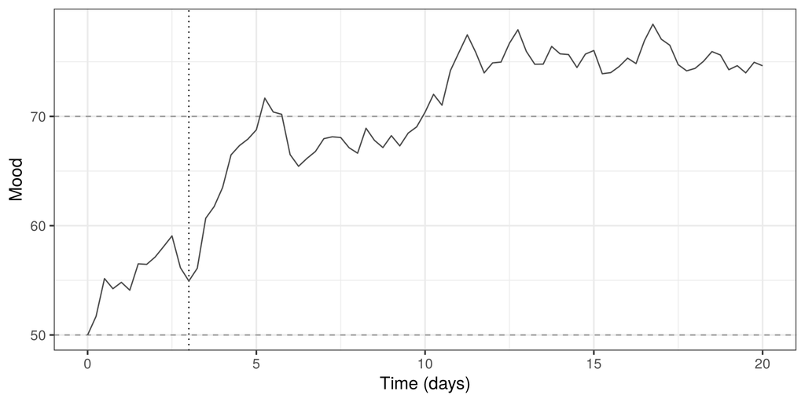

```r
ggplot(albert, aes(x = time, y = Mood)) +
  geom_vline(xintercept = shockTimes, linetype = "dotted") +
  geom_hline(yintercept = c(restMood, restMood + C * dose / -A), linetype = "dashed", colour = "grey60") +
  geom_line(colour = "grey30") +
  theme_bw(base_size = 14) +
  labs(x = "Time (days)", y = "Mood")
```

## 8.4 How do I add repeated events, e.g. weekly therapy sessions (cumulative shocks)?

Give `shockTimes` several values, e.g. `shockTimes <- seq(from = 7, to = 56, by = 7)` (8 weekly sessions). Each session adds `dose` to a process that fades slowly, so if a session comes before the last one has faded, the process builds up.

The process levels off around `dose / (-Ainput * gap)`, where `gap` is the time between sessions. Compare with transient sessions, which hit mood directly and do not build up.

```r
library(ggplot2)

times <- seq(from = 0, to = 84, by = 0.25)
Nsteps <- 20
A <- -0.5
restMood <- 50
B <- -A * restMood
G <- 3
C <- 1
Ainput <- -0.1                                 # fades slowly: half-life 6.9 days
shockTimes <- seq(from = 7, to = 56, by = 7)   # <-- CHANGE: sessions on days 7, 14, ..., 56
dose <- 3

simulateMood <- function(G, times, Nsteps){
  Nobs <- length(times)
  Mood <- Input <- rep(NA, Nobs)
  MoodState <- restMood
  InputState <- 0
  for(i in 1:Nobs){
    if(i > 1){
      dt <- (times[i] - times[i-1]) / Nsteps
      for(stepi in 1:Nsteps){
        dMood <- A*MoodState + B + C*InputState
        dInput <- Ainput*InputState
        kick <- G * sqrt(dt) * rnorm(1)
        MoodState <- MoodState + dMood * dt + kick
        InputState <- InputState + dInput * dt
      }
    }
    if(any(abs(times[i] - shockTimes) < 1e-8)) InputState <- InputState + dose   # every session
    Mood[i] <- MoodState
    Input[i] <- InputState
  }
  data.frame(time = times, Mood = Mood, Input = Input)
}

gap <- shockTimes[2] - shockTimes[1]
dose / (-Ainput * gap)                          # where the process levels off
```

```
## [1] 4.285714
```

```r
restMood + C * (dose / (-Ainput * gap)) / -A    # where mood levels off
```

```
## [1] 58.57143
```

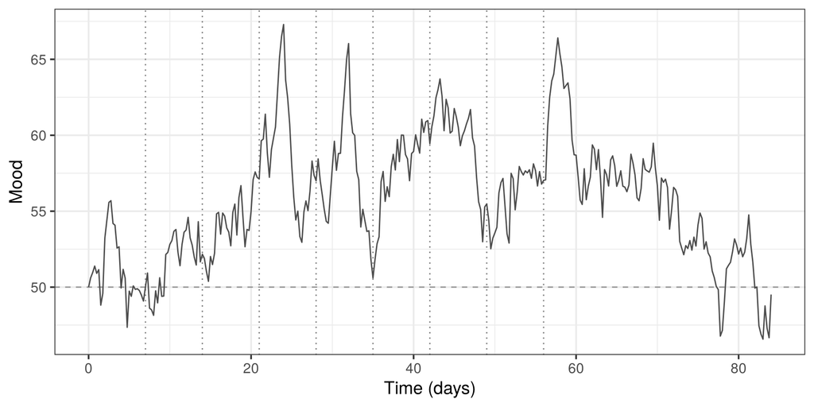

```r
set.seed(36)
albert <- simulateMood(G = G, times = times, Nsteps = Nsteps)

ggplot(albert, aes(x = time, y = Mood)) +
  geom_vline(xintercept = shockTimes, linetype = "dotted", colour = "grey50") +
  geom_hline(yintercept = restMood, linetype = "dashed", colour = "grey60") +
  geom_line(colour = "grey30") +
  theme_bw(base_size = 14) +
  labs(x = "Time (days)", y = "Mood")
```

## 8.5 How do I add an event that makes mood swing back and forth (oscillating shock)?

The shock process becomes a damped spring with two states, its position `InputState` and its speed `SpeedState`: `dSpeed <- Aspring*InputState + Adamp*SpeedState`, and `InputState` moves with the speed. Mood is pushed by `C*InputState` as before.

`Aspring <- -(2*pi/period)^2` sets how long one full swing takes; `Adamp` (negative) is the friction. In each small step, update the speed first and then move `InputState` with the **new** speed; otherwise the swings grow instead of dying out.

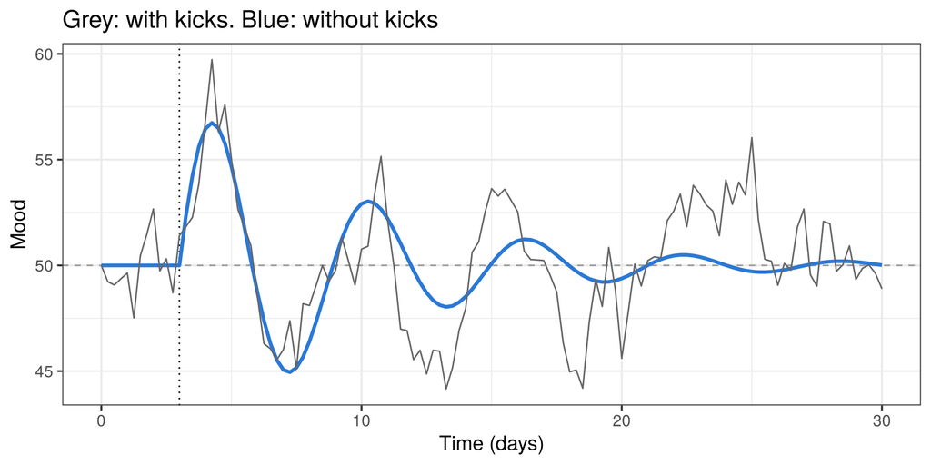

```r
library(ggplot2)

times <- seq(from = 0, to = 30, by = 0.25)
Nsteps <- 20
A <- -0.5
restMood <- 50
B <- -A * restMood
G <- 3
C <- 1
shockTimes <- 3
dose <- 10
period <- 6                       # <-- NEW: one full swing takes about 6 days
Aspring <- -(2*pi/period)^2       # <-- NEW: pull of the spring back to 0
Adamp <- -0.3                     # <-- NEW: friction

simulateMood <- function(G, times, Nsteps){
  Nobs <- length(times)
  Mood <- Input <- rep(NA, Nobs)
  MoodState <- restMood
  InputState <- 0
  SpeedState <- 0   # <-- NEW: the speed of the process
  for(i in 1:Nobs){
    if(i > 1){
      dt <- (times[i] - times[i-1]) / Nsteps
      for(stepi in 1:Nsteps){
        dMood <- A*MoodState + B + C*InputState
        dSpeed <- Aspring*InputState + Adamp*SpeedState   # <-- NEW: spring and friction
        kick <- G * sqrt(dt) * rnorm(1)
        MoodState <- MoodState + dMood * dt + kick
        SpeedState <- SpeedState + dSpeed * dt   # <-- NEW: first the speed ...
        InputState <- InputState + SpeedState * dt   # <-- NEW: ... then move with the NEW speed
      }
    }
    if(any(abs(times[i] - shockTimes) < 1e-8)) InputState <- InputState + dose
    Mood[i] <- MoodState
    Input[i] <- InputState
  }
  data.frame(time = times, Mood = Mood, Input = Input)
}

set.seed(37)
albert <- simulateMood(G = G, times = times, Nsteps = Nsteps)
clean <- simulateMood(G = 0, times = times, Nsteps = Nsteps)

ggplot(albert, aes(x = time, y = Mood)) +
  geom_vline(xintercept = shockTimes, linetype = "dotted") +
  geom_hline(yintercept = restMood, linetype = "dashed", colour = "grey60") +
  geom_line(data = clean, colour = "#2a78d6", linewidth = 1.2) +
  geom_line(colour = "grey40") +
  theme_bw(base_size = 14) +
  labs(x = "Time (days)", y = "Mood", title = "Grey: with kicks. Blue: without kicks")
```

## 8.6 How do I add an event that lasts a while instead of a moment?

Inside the small-step loop, add a push `dose / duration` to the slope while the event lasts: `if (tNow >= eventStart & tNow < eventStart + duration) dMood <- dMood + dose / duration`.

The total push is still `dose`, spread over `duration` days. As the duration gets shorter, this becomes the jump of a transient shock. Example: a weekend away (2 days) against a single compliment.

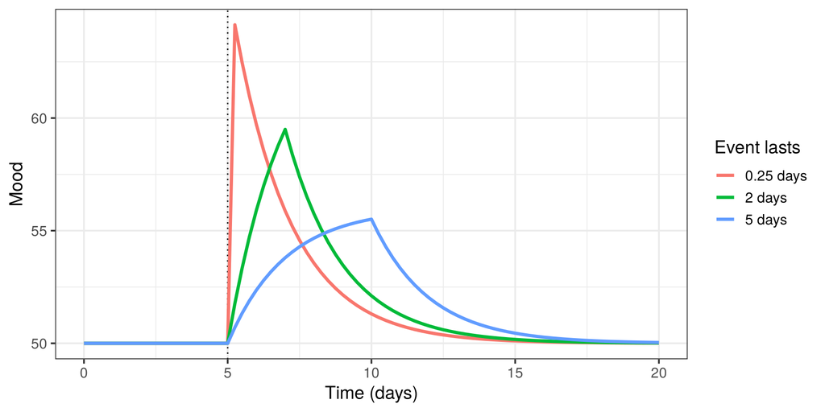

```r
library(ggplot2)

times <- seq(from = 0, to = 20, by = 0.25)
Nsteps <- 20
A <- -0.5
restMood <- 50
B <- -A * restMood
eventStart <- 5                   # <-- NEW
dose <- 15                        # <-- NEW: total push

simulateMood <- function(duration, times, Nsteps){
  Nobs <- length(times)
  Mood <- rep(NA, Nobs)
  MoodState <- restMood
  for(i in 1:Nobs){
    if(i > 1){
      dt <- (times[i] - times[i-1]) / Nsteps
      for(stepi in 1:Nsteps){
        tNow <- times[i-1] + (stepi - 1) * dt
        dMood <- A*MoodState + B
        if (tNow >= eventStart & tNow < eventStart + duration)
          dMood <- dMood + dose / duration   # <-- NEW: push while the event lasts
        MoodState <- MoodState + dMood * dt   # no kicks, to see the shape
      }
    }
    Mood[i] <- MoodState
  }
  data.frame(time = times, Mood = Mood)
}

dat <- NULL
for (d in c(0.25, 2, 5)) {
  dat <- rbind(dat, data.frame(simulateMood(duration = d, times = times, Nsteps = Nsteps),
                               duration = paste(d, "days")))
}
dat$duration <- factor(dat$duration, levels = paste(c(0.25, 2, 5), "days"))

ggplot(dat, aes(x = time, y = Mood, colour = duration)) +
  geom_vline(xintercept = eventStart, linetype = "dotted") +
  geom_line(linewidth = 1.2) +
  theme_bw(base_size = 14) +
  labs(x = "Time (days)", y = "Mood", colour = "Event lasts")
```

## 8.7 How do I add life events at random moments, different for every person?

In every small step, let an event happen with probability `eventRate * dt`: `if (runif(1) < eventRate * dt) MoodState <- MoodState + rnorm(1, eventMean, eventSD)`. Events then happen at any moment, not only at rating times, on average `eventRate` times per day.

This is a simple way to model life events: rare, sudden, and of different sizes. Because the check is inside the small-step loop, no event time has to match a rating time. The same idea works for the other shock types: add the jump to `InputState` instead of `MoodState`.

```r
library(ggplot2)

Npeople <- 4
times <- seq(from = 0, to = 56, by = 0.25)
Nsteps <- 20
A <- -0.5
restMood <- 50
B <- -A * restMood
G <- 2
eventRate <- 1/14                 # <-- NEW: on average one event every two weeks
eventMean <- -12                  # <-- NEW: events lower mood on average ...
eventSD <- 6                      # <-- NEW: ... by different amounts

simulateMood <- function(times, Nsteps){
  Nobs <- length(times)
  Mood <- rep(NA, Nobs)
  MoodState <- restMood
  events <- c()   # <-- NEW: keep track of when events happen
  for(i in 1:Nobs){
    if(i > 1){
      dt <- (times[i] - times[i-1]) / Nsteps
      for(stepi in 1:Nsteps){
        dMood <- A*MoodState + B
        kick <- G * sqrt(dt) * rnorm(1)
        MoodState <- MoodState + dMood * dt + kick
        if (runif(1) < eventRate * dt) {   # <-- NEW: does an event happen now?
          MoodState <- MoodState + rnorm(1, eventMean, eventSD)
          events <- c(events, times[i-1] + stepi * dt)
        }
      }
    }
    Mood[i] <- MoodState
  }
  list(data = data.frame(time = times, Mood = Mood), events = events)
}

set.seed(38)
dat <- NULL; eventDat <- NULL
for (p in 1:Npeople) {
  sim <- simulateMood(times, Nsteps)
  dat <- rbind(dat, data.frame(id = p, sim$data))
  if (length(sim$events) > 0) eventDat <- rbind(eventDat, data.frame(id = p, time = sim$events))
}
table(eventDat$id)                # number of events per person
```

```
##
## 1 2 3 4
## 1 4 4 5
```

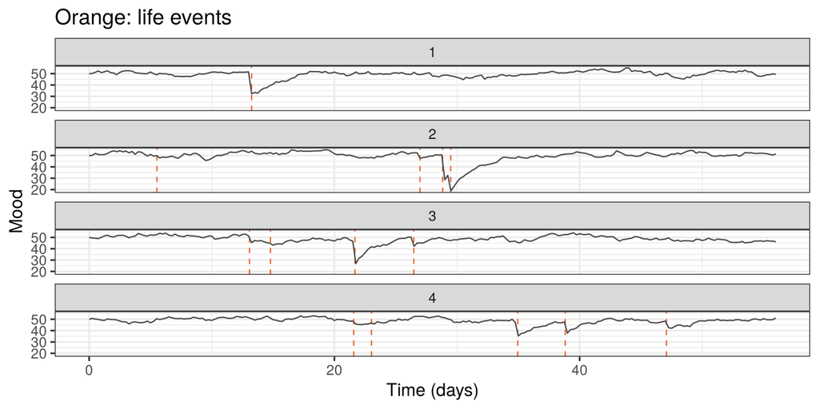

```r
ggplot(dat, aes(x = time, y = Mood)) +
  geom_vline(data = eventDat, aes(xintercept = time), colour = "#eb6834", linetype = "dashed") +
  geom_line(colour = "grey30") +
  facet_wrap(~ id, ncol = 1) +
  theme_bw(base_size = 14) +
  labs(x = "Time (days)", y = "Mood", title = "Orange: life events")
```

# 9 Scenarios, saving and checking

## 9.1 How do I compare scenarios (“what if A were different”)?

Put the values you want to compare in a vector and loop over them. Call `set.seed()` at the start of each run, so all scenarios get the same kicks and differ only in the parameter. Add a column that says which scenario a row belongs to.

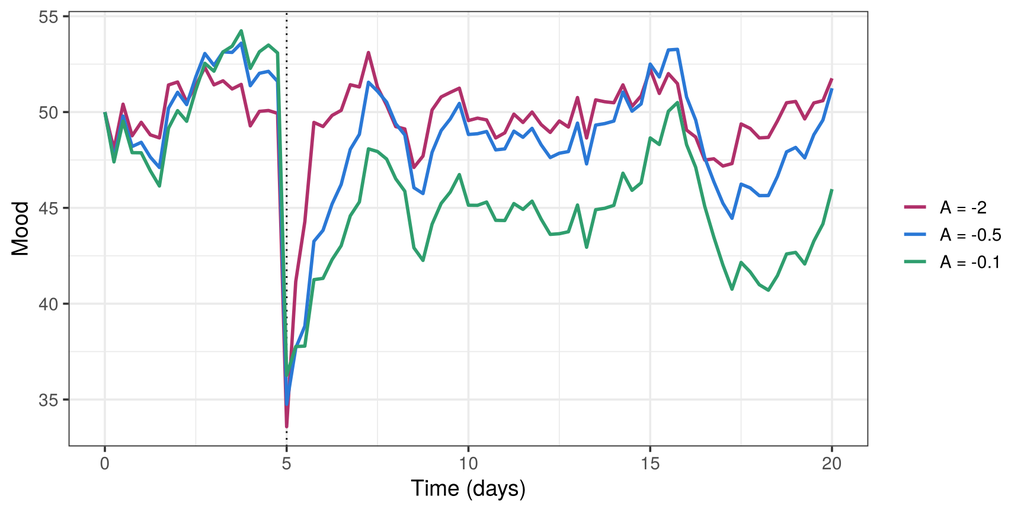

```r
library(ggplot2)

times <- seq(from = 0, to = 20, by = 0.25)
Nsteps <- 20
restMood <- 50
G <- 3
shockTimes <- 5
dose <- -15                       # a fight with a friend on day 5

simulateMood <- function(A, G, times, Nsteps){
  B <- -A * restMood
  Nobs <- length(times)
  Mood <- rep(NA, Nobs)
  MoodState <- restMood
  for(i in 1:Nobs){
    if(i > 1){
      dt <- (times[i] - times[i-1]) / Nsteps
      for(stepi in 1:Nsteps){
        dMood <- A*MoodState + B
        kick <- G * sqrt(dt) * rnorm(1)
        MoodState <- MoodState + dMood * dt + kick
      }
    }
    if(any(abs(times[i] - shockTimes) < 1e-8)) MoodState <- MoodState + dose
    Mood[i] <- MoodState
  }
  data.frame(time = times, Mood = Mood)
}

Avalues <- c(-2, -0.5, -0.1)                                 # <-- NEW: the scenarios
dat <- NULL
for (Avalue in Avalues) {
  set.seed(2026)   # same kicks in every scenario
  sim <- simulateMood(A = Avalue, G = G, times = times, Nsteps = Nsteps)
  sim$scenario <- paste("A =", Avalue)
  dat <- rbind(dat, sim)
}
dat$scenario <- factor(dat$scenario, levels = paste("A =", Avalues))   # keep the order

ggplot(dat, aes(x = time, y = Mood, colour = scenario)) +
  geom_vline(xintercept = shockTimes, linetype = "dotted") +
  geom_line(linewidth = 1) +
  scale_colour_manual(values = c("#b0306a", "#2a78d6", "#2f9e6e")) +
  theme_bw(base_size = 14) +
  labs(x = "Time (days)", y = "Mood", colour = NULL)
```

To compare **two** parameters at once (for example `A` and `G`), use two nested loops, or `expand.grid(A = c(-2, -0.5), G = c(1, 5))` and loop over its rows. Then use `facet_grid(G ~ A)` in the plot.

## 9.2 How do I save my data and my plots?

Data: `write.csv(dat, "mydata.csv", row.names = FALSE)`. Plots: store the plot in an object and use `ggsave("plots/figure1.png", p, width = 9, height = 5, dpi = 300)`.

Files are saved in your **working directory** (`getwd()` shows where that is). In RStudio, *Session > Set Working Directory > To Source File Location* saves next to your script.

```r
library(ggplot2)

times <- seq(from = 0, to = 14, by = 0.25)
Nsteps <- 20
A <- -0.5; B <- 25; G <- 3

simulateMood <- function(A, B, G, initialMood, times, Nsteps){
  Nobs <- length(times)
  Mood <- rep(NA, Nobs)
  MoodState <- initialMood
  for(i in 1:Nobs){
    if(i > 1){
      dt <- (times[i] - times[i-1]) / Nsteps
      for(stepi in 1:Nsteps){
        dMood <- A*MoodState + B
        kick <- G * sqrt(dt) * rnorm(1)
        MoodState <- MoodState + dMood * dt + kick
      }
    }
    Mood[i] <- MoodState
  }
  data.frame(time = times, Mood = Mood)
}

set.seed(39)
albert <- simulateMood(A, B, G, initialMood = 50, times = times, Nsteps = Nsteps)

write.csv(albert, "albert_simulated.csv", row.names = FALSE)    # <-- NEW: save the data
albertAgain <- read.csv("albert_simulated.csv")                 # read it back in later

dir.create("plots", showWarnings = FALSE)   # <-- NEW: a folder for the plots
p1 <- ggplot(albert, aes(x = time, y = Mood)) +
  geom_line() +
  theme_bw(base_size = 14) +
  labs(x = "Time (days)", y = "Mood")
ggsave(file.path("plots", "figure1_albert.png"), p1, width = 9, height = 5, dpi = 300)   # <-- NEW
```

This chunk is not run when the guide is knitted, so that it does not write files on your computer.

## 9.3 How do I plot many people: one panel each, or all together with the mean?

One panel per person: `facet_wrap(~ id)`. All in one panel: `aes(group = id)` with transparent lines, plus the mean over people per time point from `aggregate(Mood ~ time, data = dat, FUN = mean)`.

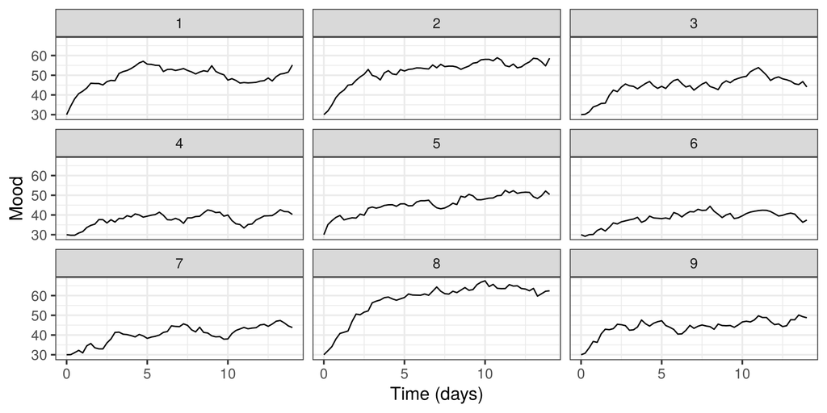

```r
library(ggplot2)

Npeople <- 30
times <- seq(from = 0, to = 14, by = 0.25)
Nsteps <- 20
A <- -0.5; G <- 3

simulateMood <- function(A, B, G, initialMood, times, Nsteps){
  Nobs <- length(times)
  Mood <- rep(NA, Nobs)
  MoodState <- initialMood
  for(i in 1:Nobs){
    if(i > 1){
      dt <- (times[i] - times[i-1]) / Nsteps
      for(stepi in 1:Nsteps){
        dMood <- A*MoodState + B
        kick <- G * sqrt(dt) * rnorm(1)
        MoodState <- MoodState + dMood * dt + kick
      }
    }
    Mood[i] <- MoodState
  }
  data.frame(time = times, Mood = Mood)
}

set.seed(40)
restLevels <- rnorm(Npeople, mean = 50, sd = 8)
dat <- NULL
for (p in 1:Npeople) {
  sim <- simulateMood(A, B = -A * restLevels[p], G, initialMood = 30, times = times, Nsteps = Nsteps)
  dat <- rbind(dat, data.frame(id = p, sim))
}

# (a) one panel per person, for the first 9 people
ggplot(dat[dat$id <= 9, ], aes(x = time, y = Mood)) +
  geom_line() +
  facet_wrap(~ id) +
  theme_bw(base_size = 14) +
  labs(x = "Time (days)", y = "Mood")
```

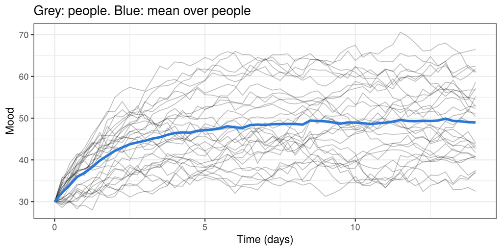

```r
# (b) everyone in one panel, with the mean over people
meanDat <- aggregate(Mood ~ time, data = dat, FUN = mean)
ggplot(dat, aes(x = time, y = Mood)) +
  geom_line(aes(group = id), alpha = 0.25) +
  geom_line(data = meanDat, colour = "#2a78d6", linewidth = 1.5) +
  theme_bw(base_size = 14) +
  labs(x = "Time (days)", y = "Mood", title = "Grey: people. Blue: mean over people")
```

The mean curve is not the curve of a typical person. Averaging people who differ (in level, speed or timing of events) smooths out what each of them does. Always look at some individual people too.

## 9.4 How do I check that my simulation is right?

Four checks: (1) without kicks and starting at rest, nothing moves; (2) without kicks, the path matches the exact solution; (3) with kicks, the long-run SD is close to `G / sqrt(2 * -A)`; (4) doubling `Nsteps` changes almost nothing.

These checks are for the basic model. For your own model, (1) and (4) always work. For (2) and (3), use any number your model predicts: an equilibrium, a half-life, a level where a process should level off.

```r
times <- seq(from = 0, to = 20, by = 0.25)
Nsteps <- 20
A <- -0.5
restMood <- 50
B <- -A * restMood

simulateMood <- function(A, B, G, initialMood, times, Nsteps){
  Nobs <- length(times)
  Mood <- rep(NA, Nobs)
  MoodState <- initialMood
  for(i in 1:Nobs){
    if(i > 1){
      dt <- (times[i] - times[i-1]) / Nsteps
      for(stepi in 1:Nsteps){
        dMood <- A*MoodState + B
        kick <- G * sqrt(dt) * rnorm(1)
        MoodState <- MoodState + dMood * dt + kick
      }
    }
    Mood[i] <- MoodState
  }
  data.frame(time = times, Mood = Mood)
}

# (1) no kicks, start at rest: should stay at 50
check1 <- simulateMood(A, B, G = 0, initialMood = restMood, times = times, Nsteps = Nsteps)
range(check1$Mood)
```

```
## [1] 50 50
```

```r
# (2) no kicks, start at 20: compare with restMood + (start - restMood) * exp(A * t)
check2 <- simulateMood(A, B, G = 0, initialMood = 20, times = times, Nsteps = Nsteps)
exact <- restMood + (20 - restMood) * exp(A * times)
max(abs(check2$Mood - exact))     # small (Euler's method is not exact, but close)
```

```
## [1] 0.03457879
```

```r
# (3) with kicks, a long run: SD around the rest should be close to G / sqrt(2 * -A)
set.seed(41)
G <- 3
check3 <- simulateMood(A, B, G, initialMood = restMood,
                       times = seq(from = 0, to = 2000, by = 0.25), Nsteps = Nsteps)
c(simulated = sd(check3$Mood), expected = G / sqrt(2 * -A))
```

```
## simulated  expected
##   3.07164   3.00000
```

```r
# (4) double Nsteps: the result should hardly change
check4 <- simulateMood(A, B, G = 0, initialMood = 20, times = times, Nsteps = 2 * Nsteps)
max(abs(check4$Mood - check2$Mood))
```

```
## [1] 0.01731196
```

## 9.5 Something goes wrong: common problems and their fixes

| What you see | Likely cause | Fix |
| --- | --- | --- |
| Values become huge (`1e+50`, `Inf`, `NaN`) | `A` is positive, a coupled system is unstable, or the small steps are too big | Check the sign of `A`; check the couplings (Stability); increase `Nsteps` |
| A zigzag that the model should not have | Small steps too big (`abs(A) * dt` near or above 1) | Increase `Nsteps` |
| Every line is completely flat | `G` is 0 and everyone starts at rest, or the kick is not added to the state | Check the update line: `... + dMood * dt + kick` |
| The line does not move away from the start, or `NA` everywhere | The state is never updated, or `initialMood` is `NA` | Print `MoodState` inside the loop for a few steps |
| The shock does not show | The shock time is not one of the rating times, or `==` misses it | Use `abs(times[i] - shockTimes) < 1e-8`; check `shockTimes %in% times` |
| Results change when I add something unrelated | The extra code draws random numbers, so later kicks change | Call `set.seed()` right before each simulation you compare |
| A scenario uses the wrong value | A parameter from an earlier run is still in the workspace | Restart R (*Session > Restart R*) and run the script from the top |
| `object 'xyz' not found` | A setting is used before it is defined, or defined only inside a function | Define all settings at the top, before the function |
| Everyone looks the same | The person values are drawn but not passed to the function | Use `A = people$A[i]`, not `A = A`, inside the people loop |
| The simulation is slow | Many people x many ratings x `Nsteps` small steps | Simulate fewer people first; increase `Nsteps` only as far as check (4) needs |

Albert, the rabbit and all data in this guide are fictional and simulated. The scripts follow the simulation scripts used in the course.